# Lab 4—Leveraging File System Structure

Brooke Anderson

## Reading in data from multiple files

In an earlier lab, we looked at how we could write a function to read in and clean data from a file in a certain format. Here, we’ll look at how we can pair that with a mapping function from the `purrr` package, as well as with system calls in R and the file system to work efficiently with data from many files.

Here are the functions we defined in earlier labs:

```r
library(dplyr)

# To run this function, you will need to have the following functions installed:
# readr, janitor, dplyr, lubridate
read_and_clean_call_data <- function(file, remove_partial_years = FALSE){

  # Read in data and clean column names
  call_data <- readr::read_csv(file = file) %>%
    janitor::clean_names() %>%
    dplyr::rename(datetime_call = date_and_time_of_initial_call)

  # Limit to columns we'll need for our research question
  call_data <- call_data %>%
    dplyr::select(datetime_call, property, location, species_description,
                  animal_class, final_ranger_action)

  call_data <- call_data %>%
    # Convert date-time column to appropriate data type
    dplyr::mutate(datetime_call = lubridate::mdy_hms(datetime_call)) %>%
    # Add columns for the year and month of the call
    dplyr::mutate(call_year = lubridate::year(datetime_call),
                  call_month = lubridate::month(datetime_call,
                                                label = TRUE,
                                                abbr = FALSE))

  if(remove_partial_years == TRUE) {
    call_data <- call_data %>%
      dplyr::filter(call_year %in% c(2019, 2020))
  }

  return(call_data)
}

# To run this function, you will need to have the following packages installed:
# dplyr
count_monthly_calls <- function(call_data) {
  monthly_calls <- call_data %>%
    dplyr::count(call_month, .drop = FALSE)

  return(monthly_calls)
}
```

We could use the function that we wrote (`read_and_clean_call_data`) to read in the data from each file:

```r
bronx_calls <- read_and_clean_call_data("../data/Bronx_animal_response.csv",
                                            remove_partial_years = TRUE)
brooklyn_calls <- read_and_clean_call_data("../data/Brooklyn_animal_response.csv",
                                            remove_partial_years = TRUE)
manhattan_calls <- read_and_clean_call_data("../data/Manhattan_animal_response.csv",
                                            remove_partial_years = TRUE)
queens_calls <- read_and_clean_call_data("../data/Queens_animal_response.csv",
                                            remove_partial_years = TRUE)
staten_island_calls <- read_and_clean_call_data("../data/Staten_Island_animal_response.csv",
                                            remove_partial_years = TRUE)
```

Already, this had made our code more efficient than if we wrote the code to read and clean each file separately. At this point, you could run code to separately generate monthly counts of calls for reptiles and amphibians for each borough:

```r
# Filter to data on reptiles and amphibians in the Bronx
bronx_calls <- bronx_calls %>%
  filter(animal_class == "Terrestrial Reptile or Amphibian")

# Count number of response calls per month in the Bronx
monthly_bronx_calls <- count_monthly_calls(bronx_calls)
monthly_bronx_calls
```

```
## # A tibble: 12 × 2
##    call_month     n
##    <ord>      <int>
##  1 January        0
##  2 February       0
##  3 March          0
##  4 April          2
##  5 May            2
##  6 June           4
##  7 July           1
##  8 August         1
##  9 September      1
## 10 October        0
## 11 November       1
## 12 December       0
```

```r
# Filter to data on reptiles and amphibians in Brooklyn
brooklyn_calls <- brooklyn_calls %>%
  filter(animal_class == "Terrestrial Reptile or Amphibian")

# Count number of response calls per month in Brooklyn
monthly_brooklyn_calls <- count_monthly_calls(brooklyn_calls)
monthly_brooklyn_calls
```

```
## # A tibble: 12 × 2
##    call_month     n
##    <ord>      <int>
##  1 January        0
##  2 February       0
##  3 March          3
##  4 April          0
##  5 May            0
##  6 June           2
##  7 July           3
##  8 August         2
##  9 September      4
## 10 October        2
## 11 November       1
## 12 December       0
```

```r
# Filter to data on reptiles and amphibians in Manhattan
manhattan_calls <- manhattan_calls %>%
  filter(animal_class == "Terrestrial Reptile or Amphibian")

# Count number of response calls per month in Manhattan
monthly_manhattan_calls <- count_monthly_calls(manhattan_calls)
monthly_manhattan_calls
```

```
## # A tibble: 12 × 2
##    call_month     n
##    <ord>      <int>
##  1 January        0
##  2 February       1
##  3 March          1
##  4 April          1
##  5 May            7
##  6 June           4
##  7 July           5
##  8 August         2
##  9 September      2
## 10 October        2
## 11 November       0
## 12 December       0
```

```r
# Filter to data on reptiles and amphibians in Queens
queens_calls <- queens_calls %>%
  filter(animal_class == "Terrestrial Reptile or Amphibian")

# Count number of response calls per month in Queens
monthly_queens_calls <- count_monthly_calls(queens_calls)
monthly_queens_calls
```

```
## # A tibble: 12 × 2
##    call_month     n
##    <ord>      <int>
##  1 January        1
##  2 February       0
##  3 March          0
##  4 April          0
##  5 May            1
##  6 June           2
##  7 July           0
##  8 August         2
##  9 September      2
## 10 October        0
## 11 November       0
## 12 December       0
```

```r
# Filter to data on reptiles and amphibians in Staten Island
staten_island_calls <- staten_island_calls %>%
  filter(animal_class == "Terrestrial Reptile or Amphibian")

# Count number of response calls per month in Staten Island
monthly_staten_island_calls <- count_monthly_calls(staten_island_calls)
monthly_staten_island_calls
```

```
## # A tibble: 12 × 2
##    call_month     n
##    <ord>      <int>
##  1 January        0
##  2 February       0
##  3 March          0
##  4 April          0
##  5 May            8
##  6 June          12
##  7 July           1
##  8 August         0
##  9 September      4
## 10 October        4
## 11 November       1
## 12 December       0
```

Notice, though, how often we’re having to copy and paste this code, even when we use our function. We could remove a lot of this if we bind all the data together into one big dataframe after we read it in but before we do anything else.

If you have several dataframes that all have the same format in terms of the number of columns, names of those columns, and types of data in those columns, you can join them into one big dataframe with the function `bind_rows` from the `dplyr` package:

```r
library(dplyr)
ny_calls <- bind_rows(bronx_calls, brooklyn_calls, manhattan_calls,
                      queens_calls, staten_island_calls)
ny_calls
```

```
## # A tibble: 92 × 8
##    datetime_call       property        location species_description animal_class
##    <dttm>              <chr>           <chr>    <chr>               <chr>
##  1 2020-11-11 13:30:00 Van Cortlandt … Van Cor… Red-eared Slider    Terrestrial…
##  2 2020-09-05 13:15:00 Pelham Bay Park Outside… Red-eared slider    Terrestrial…
##  3 2020-08-07 12:00:00 Pelham Bay Park Pelham … Red-eared Slider    Terrestrial…
##  4 2020-06-19 08:20:00 Van Cortlandt … Tennis … Red-eared Slider    Terrestrial…
##  5 2020-06-08 14:05:00 Van Cortlandt … Parade … Red-eared Slider    Terrestrial…
##  6 2020-06-04 14:15:00 Van Cortlandt … Parade … Red-eared Slider    Terrestrial…
##  7 2020-05-03 13:30:00 Van Cortlandt … Putnam … Common Snapping Tu… Terrestrial…
##  8 2019-07-23 13:00:00 Van Cortlandt … Birding… Common Snapping Tu… Terrestrial…
##  9 2019-06-17 09:00:00 Pelham Bay Park Between… Black Racer Snake   Terrestrial…
## 10 2019-05-05 09:05:00 Van Cortlandt … Van Cor… Turtle (Unknown)    Terrestrial…
## # ℹ 82 more rows
## # ℹ 3 more variables: final_ranger_action <chr>, call_year <dbl>,
## #   call_month <ord>
```

However, as we did this, we lost the information about which borough each call came from. To keep track of which borough each call comes from, we’ll add a “borough” column to each dataframe before we bind them together.

```r
bronx_calls <- bronx_calls %>%
  mutate(borough = "Bronx")
brooklyn_calls <- brooklyn_calls %>%
  mutate(borough = "Brooklyn")
manhattan_calls <- manhattan_calls %>%
  mutate(borough = "Manhattan")
queens_calls <- queens_calls %>%
  mutate(borough = "Queens")
staten_island_calls <- staten_island_calls %>%
  mutate(borough = "Staten Island")

ny_calls <- bind_rows(bronx_calls, brooklyn_calls, manhattan_calls,
                      queens_calls, staten_island_calls)
ny_calls
```

```
## # A tibble: 92 × 9
##    datetime_call       property        location species_description animal_class
##    <dttm>              <chr>           <chr>    <chr>               <chr>
##  1 2020-11-11 13:30:00 Van Cortlandt … Van Cor… Red-eared Slider    Terrestrial…
##  2 2020-09-05 13:15:00 Pelham Bay Park Outside… Red-eared slider    Terrestrial…
##  3 2020-08-07 12:00:00 Pelham Bay Park Pelham … Red-eared Slider    Terrestrial…
##  4 2020-06-19 08:20:00 Van Cortlandt … Tennis … Red-eared Slider    Terrestrial…
##  5 2020-06-08 14:05:00 Van Cortlandt … Parade … Red-eared Slider    Terrestrial…
##  6 2020-06-04 14:15:00 Van Cortlandt … Parade … Red-eared Slider    Terrestrial…
##  7 2020-05-03 13:30:00 Van Cortlandt … Putnam … Common Snapping Tu… Terrestrial…
##  8 2019-07-23 13:00:00 Van Cortlandt … Birding… Common Snapping Tu… Terrestrial…
##  9 2019-06-17 09:00:00 Pelham Bay Park Between… Black Racer Snake   Terrestrial…
## 10 2019-05-05 09:05:00 Van Cortlandt … Van Cor… Turtle (Unknown)    Terrestrial…
## # ℹ 82 more rows
## # ℹ 4 more variables: final_ranger_action <chr>, call_year <dbl>,
## #   call_month <ord>, borough <chr>
```

At this point, you could use grouping and mapping to get the monthly calls for reptiles and amphibians from each borough, directly after reading in the data from each borough and binding them with `bind_rows`:

```r
library(tidyr)
library(purrr)

ny_monthly_calls <- ny_calls %>%
  filter(animal_class == "Terrestrial Reptile or Amphibian") %>%
  nest(.by = borough) %>%
  mutate(monthly_counts = map(data, count_monthly_calls)) %>%
  select(borough, monthly_counts) %>%
  unnest(cols = c(monthly_counts))
ny_monthly_calls
```

```
## # A tibble: 60 × 3
##    borough call_month     n
##    <chr>   <ord>      <int>
##  1 Bronx   January        0
##  2 Bronx   February       0
##  3 Bronx   March          0
##  4 Bronx   April          2
##  5 Bronx   May            2
##  6 Bronx   June           4
##  7 Bronx   July           1
##  8 Bronx   August         1
##  9 Bronx   September      1
## 10 Bronx   October        0
## # ℹ 50 more rows
```

And now it’s very easy to use the data to create a plot to visualize the results:

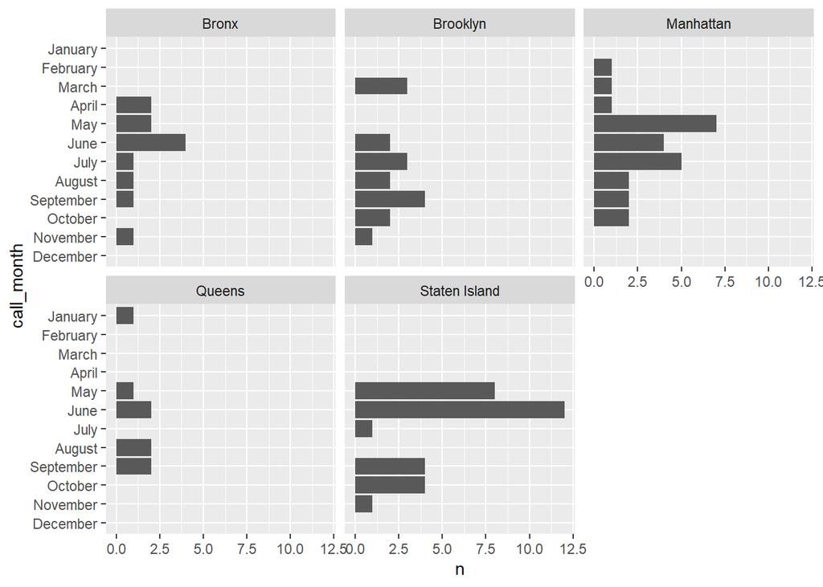

```r
library(ggplot2)
ny_monthly_calls %>%
  ggplot(aes(x = n, y = call_month)) +
  geom_col() +
  scale_y_discrete(limits = rev) +
  facet_wrap(~ borough)
```

As a note, I’ve made some minor changes to the plotting code compared to when we plotted the values for a single borough in the last lab. Since the month names are long, I’ve put them on the y-axis, so they’re easier to read, and I’ve reversed the order of that y-axis so it reads from January to December from top to bottom—use your dissecting tools if you’re not clear on how these changes work!

At this point, the full script would look like this:

```r
# Load required libraries ##############################################################
library(readr)
library(janitor)
library(dplyr)
library(lubridate)
library(tidyr)
library(purrr)
library(ggplot2)

# Define functions ####################################################################

# To run this function, you will need to have the following functions installed:
# readr, janitor, dplyr, lubridate
read_and_clean_call_data <- function(file, remove_partial_years = FALSE){

  # Read in data and clean column names
  call_data <- readr::read_csv(file = file) %>%
    janitor::clean_names() %>%
    dplyr::rename(datetime_call = date_and_time_of_initial_call)

  # Limit to columns we'll need for our research question
  call_data <- call_data %>%
    dplyr::select(datetime_call, property, location, species_description,
                  animal_class, final_ranger_action)

  call_data <- call_data %>%
    # Convert date-time column to appropriate data type
    dplyr::mutate(datetime_call = lubridate::mdy_hms(datetime_call)) %>%
    # Add columns for the year and month of the call
    dplyr::mutate(call_year = lubridate::year(datetime_call),
                  call_month = lubridate::month(datetime_call,
                                                label = TRUE,
                                                abbr = FALSE))

  if(remove_partial_years == TRUE) {
    call_data <- call_data %>%
      dplyr::filter(call_year %in% c(2019, 2020))
  }

  return(call_data)
}

# To run this function, you will need to have the following packages installed:
# dplyr
count_monthly_calls <- function(call_data) {
  monthly_calls <- call_data %>%
    dplyr::count(call_month, .drop = FALSE)

  return(monthly_calls)
}

# Run analysis ########################################################################

# Read in data from each borough
bronx_calls <- read_and_clean_call_data("../data/Bronx_animal_response.csv",
                                            remove_partial_years = TRUE)
brooklyn_calls <- read_and_clean_call_data("../data/Brooklyn_animal_response.csv",
                                            remove_partial_years = TRUE)
manhattan_calls <- read_and_clean_call_data("../data/Manhattan_animal_response.csv",
                                            remove_partial_years = TRUE)
queens_calls <- read_and_clean_call_data("../data/Queens_animal_response.csv",
                                            remove_partial_years = TRUE)
staten_island_calls <- read_and_clean_call_data("../data/Staten_Island_animal_response.csv",
                                            remove_partial_years = TRUE)

# Add a column for borough and bind data together into one dataframe
bronx_calls <- bronx_calls %>%
  mutate(borough = "Bronx")
brooklyn_calls <- brooklyn_calls %>%
  mutate(borough = "Brooklyn")
manhattan_calls <- manhattan_calls %>%
  mutate(borough = "Manhattan")
queens_calls <- queens_calls %>%
  mutate(borough = "Queens")
staten_island_calls <- staten_island_calls %>%
  mutate(borough = "Staten Island")

ny_calls <- bind_rows(bronx_calls, brooklyn_calls, manhattan_calls,
                      queens_calls, staten_island_calls)

# Filter to reptiles and amphibians and get monthly counts by borough
ny_monthly_calls <- ny_calls %>%
  filter(animal_class == "Terrestrial Reptile or Amphibian") %>%
  nest(.by = borough) %>%
  mutate(monthly_counts = map(data, count_monthly_calls)) %>%
  select(borough, monthly_counts) %>%
  unnest(cols = c(monthly_counts))

# Visualize the results
ny_monthly_calls %>%
  ggplot(aes(x = n, y = call_month)) +
  geom_col() +
  scale_y_discrete(limits = rev) +
  facet_wrap(~ borough)
```

This is more efficient that copying and pasting the full code for each borough. However, we can make it more efficient by leveraging the way we’ve organized our project directory, as well as system files. We can create a vector with all the file names and then use the idea of mapping functions from an earlier stage of the script to make the code more efficient.

First, we have structured our project directory so that all the data files are in the same directory, and they are the only files in that directory. Also, we’ve designed the filenames to start with the borough, so we can extract the borough information from the filenames.

In R, the `list.files` function works as a system call that will list all the files in a given directory. To list all the files in a directory called “data” that is a subdirectory of the parent directory you’re working in, you can run:

```r
list.files(path = "../data")
```

```
## [1] "Bronx_animal_response.csv"         "Brooklyn_animal_response.csv"
## [3] "Manhattan_animal_response.csv"     "Queens_animal_response.csv"
## [5] "Staten_Island_animal_response.csv"
```

As a note, this call assumes that you have the files within a subdirectory of the parent directory of your current working directory, and that the subdirectory is named “data”. If you’re unfamiliar with relative filepaths like this and are getting an error, let us know and we’ll have you make sure you have your directory arranged correctly for this and the following code to work.

We can use this `list.files` call to create a vector with the filenames of the files for all boroughs:

```r
borough_files <- list.files(path = "../data")
borough_files
```

```
## [1] "Bronx_animal_response.csv"         "Brooklyn_animal_response.csv"
## [3] "Manhattan_animal_response.csv"     "Queens_animal_response.csv"
## [5] "Staten_Island_animal_response.csv"
```

If the files are in a different directory than your working directory, you’ll want to make sure they are listed with their full pathname if we want to work with them in further code, which you can do with the parameter `full.names`:

```r
borough_files <- list.files(path = "../data", full.names = TRUE)
borough_files
```

```
## [1] "../data/Bronx_animal_response.csv"
## [2] "../data/Brooklyn_animal_response.csv"
## [3] "../data/Manhattan_animal_response.csv"
## [4] "../data/Queens_animal_response.csv"
## [5] "../data/Staten_Island_animal_response.csv"
```

Now that we have these as a vector, we can map over that vector to read in all the files. We’ll make one change in our function to read and clean the data. We want to make sure the filenames are included when we read in the data, so we can change the `read_csv` call in the function, using its `id` parameter to include the filename as a column in the final data (we’ll also need to make sure we select this column when we clean out the columns we don’t need):

```r
# To run this function, you will need to have the following functions installed:
# readr, janitor, dplyr, lubridate
read_and_clean_call_data <- function(file, remove_partial_years = FALSE){

  # Read in data and clean column names
  call_data <- readr::read_csv(file = file, id = "filename") %>%
    janitor::clean_names() %>%
    dplyr::rename(datetime_call = date_and_time_of_initial_call)

  # Limit to columns we'll need for our research question
  call_data <- call_data %>%
    dplyr::select(datetime_call, property, location, species_description,
                  animal_class, final_ranger_action, filename)

  call_data <- call_data %>%
    # Convert date-time column to appropriate data type
    dplyr::mutate(datetime_call = lubridate::mdy_hms(datetime_call)) %>%
    # Add columns for the year and month of the call
    dplyr::mutate(call_year = lubridate::year(datetime_call),
                  call_month = lubridate::month(datetime_call,
                                                label = TRUE,
                                                abbr = FALSE))

  if(remove_partial_years == TRUE) {
    call_data <- call_data %>%
      dplyr::filter(call_year %in% c(2019, 2020))
  }

  return(call_data)
}


bronx_calls <- read_and_clean_call_data("../data/Bronx_animal_response.csv",
                                            remove_partial_years = TRUE)
bronx_calls
```

```
## # A tibble: 165 × 9
##    datetime_call       property        location species_description animal_class
##    <dttm>              <chr>           <chr>    <chr>               <chr>
##  1 2020-12-31 12:00:00 Pelham Bay Park "Orchar… Canada Goose        Birds
##  2 2020-12-29 12:55:00 Walton Park     "Inside… Chicken             Domestic;#B…
##  3 2020-12-28 11:30:00 Pelham Bay Park "40.869… Raccoon             Small Mamma…
##  4 2020-12-24 13:00:00 Pelham Bay Park "Orchar… White-tailed Deer   Deer
##  5 2020-12-16 12:05:00 Van Cortlandt … "Van Co… Canada Goose        Birds
##  6 2020-12-13 10:50:00 Van Cortlandt … "Van Co… Canada Goose        Birds
##  7 2020-12-10 10:20:00 Van Cortlandt … "87 Nor… Eastern Coyote      Coyotes
##  8 2020-12-08 09:30:00 Van Cortlandt … "Moshol… Chicken             Birds;#Dome…
##  9 2020-12-04 11:00:00 Pelham Bay Park "\"On t… White-tailed Deer   Deer
## 10 2020-12-03 14:00:00 Soundview Park  "Baseba… Striped Skunk       Small Mamma…
## # ℹ 155 more rows
## # ℹ 4 more variables: final_ranger_action <chr>, filename <chr>,
## #   call_year <dbl>, call_month <ord>
```

Now let’s apply this function across all the borough files:

```r
ny_calls <- borough_files %>%
  map(.f = read_and_clean_call_data, remove_partial_years = TRUE)
ny_calls
```

```
## [[1]]
## # A tibble: 165 × 9
##    datetime_call       property        location species_description animal_class
##    <dttm>              <chr>           <chr>    <chr>               <chr>
##  1 2020-12-31 12:00:00 Pelham Bay Park "Orchar… Canada Goose        Birds
##  2 2020-12-29 12:55:00 Walton Park     "Inside… Chicken             Domestic;#B…
##  3 2020-12-28 11:30:00 Pelham Bay Park "40.869… Raccoon             Small Mamma…
##  4 2020-12-24 13:00:00 Pelham Bay Park "Orchar… White-tailed Deer   Deer
##  5 2020-12-16 12:05:00 Van Cortlandt … "Van Co… Canada Goose        Birds
##  6 2020-12-13 10:50:00 Van Cortlandt … "Van Co… Canada Goose        Birds
##  7 2020-12-10 10:20:00 Van Cortlandt … "87 Nor… Eastern Coyote      Coyotes
##  8 2020-12-08 09:30:00 Van Cortlandt … "Moshol… Chicken             Birds;#Dome…
##  9 2020-12-04 11:00:00 Pelham Bay Park "\"On t… White-tailed Deer   Deer
## 10 2020-12-03 14:00:00 Soundview Park  "Baseba… Striped Skunk       Small Mamma…
## # ℹ 155 more rows
## # ℹ 4 more variables: final_ranger_action <chr>, filename <chr>,
## #   call_year <dbl>, call_month <ord>
##
## [[2]]
## # A tibble: 222 × 9
##    datetime_call       property        location species_description animal_class
##    <dttm>              <chr>           <chr>    <chr>               <chr>
##  1 2020-12-30 22:00:00 Sunset Park     7th Ave… Chicken             Domestic;#B…
##  2 2020-12-20 11:30:00 Bush Terminal … Marsh R… Canada Goose        Birds
##  3 2020-12-08 10:30:00 Fulton Park     Tree on… Red-tailed Hawk     Raptors
##  4 2020-11-24 14:00:00 Bushwick Playg… Buildin… Cat                 Domestic
##  5 2020-11-24 11:30:00 Brooklyn Bridg… Pier 4   Mute Swan           Birds
##  6 2020-11-21 13:30:00 Marine Park     In the … Brant Goose         Birds
##  7 2020-11-19 12:15:00 Shore Park and… On Bike… Mute Swan           Birds
##  8 2020-11-19 07:45:00 Bartlett Playg… park pe… Common Snapping Tu… Terrestrial…
##  9 2020-11-14 12:40:00 Sheepshead Bay… By 400 … Mute Swan           Birds
## 10 2020-11-10 16:15:00 Cadman Plaza P… N/A      Red-tailed Hawk     Raptors
## # ℹ 212 more rows
## # ℹ 4 more variables: final_ranger_action <chr>, filename <chr>,
## #   call_year <dbl>, call_month <ord>
##
## [[3]]
## # A tibble: 455 × 9
##    datetime_call       property        location species_description animal_class
##    <dttm>              <chr>           <chr>    <chr>               <chr>
```

[output cut: 34 more lines]

```
##    datetime_call       property        location species_description animal_class
##    <dttm>              <chr>           <chr>    <chr>               <chr>
##  1 2020-12-30 14:00:00 Historic Richm… Creek    Canada Goose        Birds
##  2 2020-12-30 13:45:00 Historic Richm… off Ric… Canada Goose        Birds
##  3 2020-12-29 13:00:00 Bloomingdale P… Bloomin… White-tailed Deer   Deer
##  4 2020-12-20 16:00:00 Wolfe's Pond P… On beac… Red-throated Loon   Birds
##  5 2020-12-16 09:20:00 Bloomingdale P… At Comf… Rock Dove           Birds
##  6 2020-12-16 09:00:00 Wolfe's Pond P… Picnic … Canada Goose        Birds
##  7 2020-12-13 14:20:00 Wolfe's Pond P… across … Striped Skunk       Small Mamma…
##  8 2020-12-02 14:00:00 Willowbrook Pa… Willowb… Domestic Duck       Birds;#Dome…
##  9 2020-12-07 13:45:00 Kingdom Pond P… Corner … White-tailed Deer   Deer
## 10 2020-12-01 18:40:00 Willowbrook Pa… Willowb… Domestic Duck       Domestic;#B…
## # ℹ 330 more rows
## # ℹ 4 more variables: final_ranger_action <chr>, filename <chr>,
## #   call_year <dbl>, call_month <ord>
```

This results in a list, where each element is the data from a different borough. If we want to bind them into a single dataframe, we can use `bind_rows`:

```r
ny_calls <- ny_calls %>%
  bind_rows()
```

We can use regular expressions to extract the borough name from the “filename” column. Here’s an example of what the values in the filename look like:

```r
ny_calls %>%
  pull(filename) %>%
  sample(5)
```

```
## [1] "../data/Staten_Island_animal_response.csv"
## [2] "../data/Staten_Island_animal_response.csv"
## [3] "../data/Bronx_animal_response.csv"
## [4] "../data/Queens_animal_response.csv"
## [5] "../data/Staten_Island_animal_response.csv"
```

They follow a similar pattern: the borough name is between “../data/” and “_animal_response.csv”. There are a few ways we could tackle extracting the borough names. One of the simplest (although probably not the shortest) is to get rid of everything we don’t want, which we can do with the `str_remove` function from the `stringr` package. Since “Staten Island” is two words, we’ll also want to replace the underscore between Staten and Island with a space, which we can do with `str_replace` (also from the `stringr` package). We’ll put the results in a new column called `borough`:

```r
library(stringr)
ny_calls <- ny_calls %>%
  mutate(borough = filename,
         borough = str_remove(borough, "../data/"),
         borough = str_remove(borough, "_animal_response.csv"),
         borough = str_replace(borough, "_", " "))
```

Here’s a sample of the results:

```r
ny_calls %>%
  pull(borough) %>%
  sample(10)
```

```
##  [1] "Manhattan"     "Queens"        "Staten Island" "Staten Island"
##  [5] "Staten Island" "Brooklyn"      "Queens"        "Brooklyn"
##  [9] "Staten Island" "Bronx"
```

Now we can proceed with the code to analyze the full dataset. With these changes, our full script would look like this:

```r
# Load required libraries ##############################################################
library(readr)
library(janitor)
library(dplyr)
library(lubridate)
library(tidyr)
library(purrr)
library(stringr)
library(ggplot2)

# Define functions ####################################################################

# To run this function, you will need to have the following functions installed:
# readr, janitor, dplyr, lubridate
read_and_clean_call_data <- function(file, remove_partial_years = FALSE){

  # Read in data and clean column names
  call_data <- readr::read_csv(file = file, id = "filename") %>%
    janitor::clean_names() %>%
    dplyr::rename(datetime_call = date_and_time_of_initial_call)

  # Limit to columns we'll need for our research question
  call_data <- call_data %>%
    dplyr::select(datetime_call, property, location, species_description,
                  animal_class, final_ranger_action, filename)

  call_data <- call_data %>%
    # Convert date-time column to appropriate data type
    dplyr::mutate(datetime_call = lubridate::mdy_hms(datetime_call)) %>%
    # Add columns for the year and month of the call
    dplyr::mutate(call_year = lubridate::year(datetime_call),
                  call_month = lubridate::month(datetime_call,
                                                label = TRUE,
                                                abbr = FALSE))

  if(remove_partial_years == TRUE) {
    call_data <- call_data %>%
      dplyr::filter(call_year %in% c(2019, 2020))
  }

  return(call_data)
}

# To run this function, you will need to have the following packages installed:
# dplyr
count_monthly_calls <- function(call_data) {
  monthly_calls <- call_data %>%
    dplyr::count(call_month, .drop = FALSE)

  return(monthly_calls)
}

# Run analysis ########################################################################

# Create a vector with the names of all the files
borough_files <- list.files(path = "../data", full.names = TRUE)

# Read in data from all files, bind them together, and extract borough names from
# the filenames
ny_calls <- borough_files %>%
  map(.f = read_and_clean_call_data, remove_partial_years = TRUE) %>%
  bind_rows() %>%
  mutate(borough = filename,
         borough = str_remove(borough, "../data/"),
         borough = str_remove(borough, "_animal_response.csv"),
         borough = str_replace(borough, "_", " "))

# Filter to reptiles and amphibians and get monthly counts by borough
ny_monthly_calls <- ny_calls %>%
  filter(animal_class == "Terrestrial Reptile or Amphibian") %>%
  nest(.by = borough) %>%
  mutate(monthly_counts = map(data, count_monthly_calls)) %>%
  select(borough, monthly_counts) %>%
  unnest(cols = c(monthly_counts))

# Visualize the results
ny_monthly_calls %>%
  ggplot(aes(x = n, y = call_month)) +
  geom_col() +
  scale_y_discrete(limits = rev) +
  facet_wrap(~ borough)
```

Amazingly, this script isn’t much longer than our earlier script where we were only working with data from a single borough, using a single data file. This solution avoids a lot of copying and pasting. As you work with more and more files, this type of solution will become even more helpful (imagine, for example, if you were working with files for all 50 states).

By using this functional programming solution, we’ve created a code script that is concise and will be easier to maintain, since we can make a change that applied to the data from all boroughs in a single place, rather than needing to make sure that, when we want to make a change in the code, we fix the code everywhere we’ve copy-and-pasted it throughout the script.